# Chapter 12 🧩 Independent Component Analysis (ICA)

## Introduction

**Independent Component Analysis (ICA)** is a powerful statistical and computational technique for identifying *hidden source signals* from observed mixtures. It assumes that each observed variable is a linear combination of several statistically **independent, non-Gaussian latent sources**, and aims to recover those sources using only the observed mixtures. Unlike **Principal Component Analysis (PCA)**, which decorrelates data by maximizing variance along orthogonal directions, ICA goes beyond decorrelation and seeks components that are **as statistically independent as possible**, not merely uncorrelated.

ICA uncovers **independent latent causes** underlying the data, making it ideal for separating distinct signal sources. For instance, it can isolate brain signal components in EEG recordings or separate individual instruments from a blended audio track. In contrast, **Factor Analysis** focuses on uncovering **latent constructs** that explain correlations among observed variables, for example, identifying underlying traits such as *anxiety*, *sociability*, or *intelligence* from psychological survey data.

Because of its ability to disentangle complex mixtures, ICA has become fundamental in modern applications across **neuroscience**, **telecommunications**, **image processing**, **finance**, and **econometrics**, where multiple independent processes contribute to the observed data.

| **Feature** | **PCA** | **ICA** | **Factor Analysis (FA)** |
| --- | --- | --- | --- |
| **Goal** | Maximize variance | Maximize independence | Explain correlations among variables |
| **Components / Factors** | Orthogonal principal components | Statistically independent components | Latent factors, usually uncorrelated but not independent |
| **Assumptions** | Data are Gaussian; orthogonality | Sources are non-Gaussian and independent | Factors cause correlations; includes unique error terms |
| **Noise treatment** | No explicit noise model | Typically noise-free or minimal noise assumed | Explicit unique variances for each variable |
| **Mathematical form** | $\mathbf{x} = W^{-1}\mathbf{z}$ | $\mathbf{x} = A\mathbf{s}$ | $\mathbf{x} = \Lambda\mathbf{f} + \boldsymbol{\epsilon}$ |
| **Type of relation** | Decorrelates variables | Unmixes independent sources | Models covariance structure |
| **Suitable for** | Gaussian data | Non-Gaussian mixtures | Correlated observed variables with latent structure |
| **Applications** | Dimension reduction, visualization | Signal separation, feature extraction | Psychology, education, social sciences, psychometrics |

## Motivating Example: The Cocktail Party Problem

Imagine that you are in a room where **two people are speaking simultaneously**. You have **two microphones**, placed at different locations, recording the overlapping voices. Each microphone captures a **mixture** of both speakers’ sounds.  
Let the microphone signals be $x_1(t)$ and $x_2(t)$, representing sound amplitudes at time $t$, and the true speech sources be $s_1(t)$ and $s_2(t)$. Then each observed signal is a **weighted sum** of the two true voices:

$$ \begin{cases} x_1(t) = a_{11}s_1(t) + a_{12}s_2(t), \\ x_2(t) = a_{21}s_1(t) + a_{22}s_2(t), \end{cases} $$

or equivalently,

$$ \mathbf{x}(t) = A \mathbf{s}(t), $$

where

- $\mathbf{x}(t) = [x_1(t), x_2(t)]^T$ — observed signals,
- $\mathbf{s}(t) = [s_1(t), s_2(t)]^T$ — unknown independent sources,
- $A = [a_{ij}]$ — **mixing matrix** that depends on geometry and acoustic paths.

If $A$ were known, the inverse problem would be trivial:

$$ \mathbf{s}(t) = A^{-1} \mathbf{x}(t). $$

However, in reality, both $A$ and $\mathbf{s}(t)$ are unknown — only $\mathbf{x}(t)$ is observed.

The challenge is to **recover the original speech signals** using only the mixed recordings. This is known as the **cocktail party problem**, and ICA provides an elegant, general solution. By assuming that the sources $s_1(t)$ and $s_2(t)$ are **statistically independent**, ICA estimates both the mixing matrix $A$ and the independent sources simultaneously.

In practice, ICA recovers signals $\hat{s}_1(t)$ and $\hat{s}_2(t)$ that are nearly identical to the true speech sources, up to permutation and sign changes — both of which are inconsequential.

## Applications of ICA

### (a) **Brain Signal Separation — EEG Analysis**

Consider **electrical recordings of brain activity**, such as electroencephalograms (EEGs).  
EEG data consist of electrical potentials recorded at multiple scalp locations.  
Each electrode’s signal represents a *mixture* of multiple underlying sources of neural activity within the brain.

This situation is **analogous to the cocktail party problem**: we observe only mixtures of unknown neural processes.  
Applying ICA to EEG data allows the extraction of **independent components** representing distinct physiological processes, such as:

- Specific brain regions’ activity
- Eye-blink artifacts
- Muscle or cardiac noise

ICA has become a fundamental tool in neuroscience for isolating and interpreting meaningful signals from complex multichannel recordings.

### (b) **Feature Extraction and Data Representation**

Another important use of ICA is in **feature extraction**. In digital signal or image processing, it is often desirable to find *efficient representations* of data for compression, denoising, or recognition. Traditional linear transforms such as the **Fourier**, **Haar**, or **Cosine transforms** are commonly used, each with its own mathematical advantages.

However, ICA provides a **data-driven transformation**: it estimates the linear transformation directly from the data, yielding basis functions *adapted to the statistical structure* of the dataset.

For example, when ICA is applied to patches of **natural images**, the resulting basis functions resemble **localized edge detectors** — similar to receptive fields in the human visual cortex. Each image patch can be represented as a linear combination of these basis functions, with coefficients that are statistically independent.  
This makes ICA a powerful method for **automatic feature discovery** in vision and signal analysis.

## General ICA Model

In the general case of $n$ observed mixtures:

$$ \mathbf{x} = A \mathbf{s}, $$

where

- $\mathbf{x} = (x_1, \ldots, x_n)^T$ are **observed mixtures**,
- $\mathbf{s} = (s_1, \ldots, s_n)^T$ are **independent, non-Gaussian sources**,
- $A$ is an **invertible** mixing matrix.

The ICA objective is to estimate a **demixing matrix** $W$ such that:

$$ \mathbf{s} = W \mathbf{x}, $$

and the recovered components $s_i$ are statistically independent.

## Assumptions for Identifiability

1. **Statistical independence:**
   $$ P(s_1, s_2, \ldots, s_n) = \prod_i P(s_i) $$
2. **Non-Gaussianity:** At most one component can be Gaussian.
3. **Linear and instantaneous mixing:** No time delays or convolutions.

Under these assumptions, ICA can uniquely recover the sources up to permutation and scaling.

## Preprocessing: Centering and Whitening

Prior to ICA estimation, the observed data $\mathbf{x}$ are usually:

- **Centered:**
  $$ \mathbf{x}_c = \mathbf{x} - E[\mathbf{x}] $$
- **Whitened:**
  transform $\mathbf{x}_c$ so that
  $$ \mathrm{Cov}(\mathbf{x}_c) = I $$

Whitening (often via PCA) simplifies the ICA problem since it ensures the mixed data have uncorrelated, unit-variance dimensions — making the effective mixing matrix orthogonal.

## Estimation Principle: Maximizing Non-Gaussianity

The intuition behind ICA is rooted in the **Central Limit Theorem**:

> Linear combinations of independent non-Gaussian variables tend to be more Gaussian than the original variables.

Therefore, to recover the independent components, ICA searches for directions $w$ such that $y = w^T x$ is **maximally non-Gaussian**.

### Common measures of non-Gaussianity:

- **Kurtosis:** $$ \text{Kurt}(y) = E[y^4] - 3(E[y^2])^2 $$
- **Negentropy:** $$ J(y) = H(y_{\text{gauss}}) - H(y), $$ where $H(y)$ is the differential entropy, and $y_{\text{gauss}}$ is Gaussian with the same variance.

Maximizing these measures leads to statistically independent components.

## FastICA Algorithm

The **FastICA** algorithm (Hyvärinen, 1999) is a fixed-point method for estimating $W$:

For whitened data $x$:

1. Initialize a random unit vector $w$.
2. Update iteratively: $$ w^{\text{new}} = E[x g(w^T x)] - E[g'(w^T x)] w, $$ where $g(u)$ is a nonlinear contrast function (e.g. $g(u) = \tanh(u)$).
3. Normalize: $$ w^{\text{new}} \leftarrow \frac{w^{\text{new}}}{\|w^{\text{new}}\|} $$
4. Decorrelate between components.
5. Repeat until convergence.

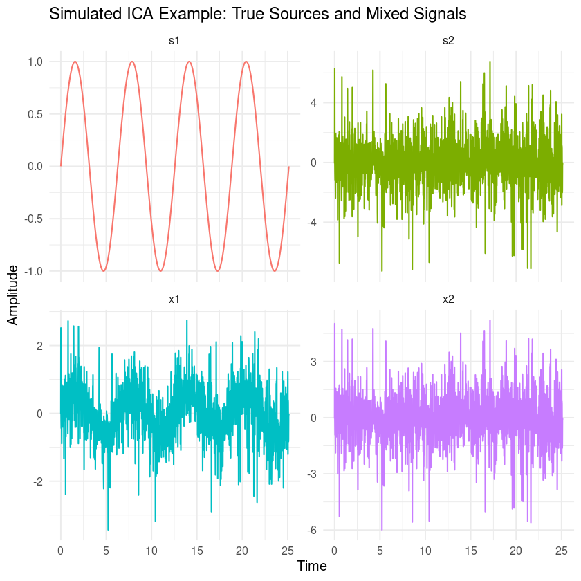

```r
## ICA Teaching Example in R
## Simulated Cocktail Party Data


# Load required package
library(ggplot2)

set.seed(121)
n <- 2000
t <- seq(0, 8 * pi, length.out = n)

s1 <- sin(t)                        # Smooth source (e.g., periodic)
s2 <- sign(rnorm(n)) * rexp(n, 1)   # Spiky, heavy-tailed source

S <- cbind(s1, s2)                  # True sources

# 2. Mixing matrix and observed mixtures
A <- matrix(c(0.6, 0.4,
              0.2, 0.8),
            nrow = 2, byrow = TRUE)
X <- S %*% t(A)                     # Mixed signals
colnames(X) <- c("x1", "x2")

# 3. Combine data for plotting
ica_data <- data.frame(
  time = t,
  s1 = S[, 1],
  s2 = S[, 2],
  x1 = X[, 1],
  x2 = X[, 2]
)


library(tidyverse)
ica_long <- ica_data %>%
  select(time, s1, s2, x1, x2) %>%
  pivot_longer(cols = -time, names_to = "Signal", values_to = "Value")

ggplot(ica_long, aes(x = time, y = Value, color = Signal)) +
  geom_line(linewidth = 0.6) +
  facet_wrap(~ Signal, ncol = 2, scales = "free_y") +
  theme_minimal(base_size = 12) +
  labs(title = "Simulated ICA Example: True Sources and Mixed Signals",
       x = "Time", y = "Amplitude") +
  theme(legend.position = "none")
```

In the R code, the two sources are generated as:

$$ \begin{aligned} s_1(t) &= \sin(t), \\ s_2(t) &= \text{sign}(z_t) \cdot \text{Exp}(1), \end{aligned} $$

where $z_t \sim N(0,1)$ and $\text{Exp}(1)$ denotes an exponential random variable.

Thus:

These two signals are **statistically independent** — they do not share a common distribution or temporal dependence.

We define the **mixing matrix** $A$ as:

$$ A = \begin{bmatrix} 0.6 & 0.4 \\ 0.2 & 0.8 \end{bmatrix} $$

Each observed signal is a **weighted combination** of the two sources:

$$ \begin{cases} x_1(t) = 0.6 s_1(t) + 0.4 s_2(t), \\ x_2(t) = 0.2 s_1(t) + 0.8 s_2(t). \end{cases} $$

This simulates two “microphones” placed in different positions within a room, each recording a distinct mixture of two voices or signals.

```r
str(X)
```

```
 num [1:2000, 1:2] -0.0252 2.5203 0.1001 -0.2399 -0.4361 ...
 - attr(*, "dimnames")=List of 2
  ..$ : NULL
  ..$ : chr [1:2] "x1" "x2"
```

```r
library(fastICA)

# ICA recovery
ica = fastICA(X, n.comp = 2)
S.recovery = ica$S   # recovered signals

str(S.recovery)
```

```
 num [1:2000, 1:2] -0.0385 4.3144 0.1513 -0.4443 -0.7931 ...
```

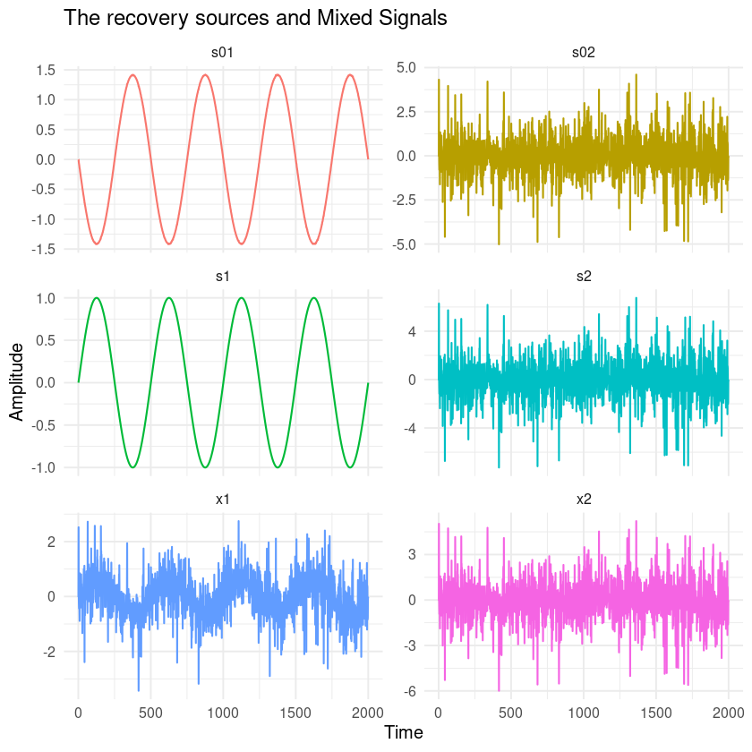

```r
ica <- fastICA(X, n.comp = 2)
S_rec <- ica$S   # recovered components

t = 1: length(X[,1])

# 3. Combine data for plotting
ica.rec = data.frame(
  time = t,
  s01 = S.recovery[, 1],
  s02 = S.recovery[, 2],
  x1 = X[, 1],
  x2 = X[, 2],
  s1 = S[, 1],
  s2 = S[, 2]
)


ica.long <- ica.rec %>%
  select(time, s01, s02, x1, x2, s1, s2) %>%
  pivot_longer(cols = -time, names_to = "Signal", values_to = "Value")

ggplot(ica.long, aes(x = time, y = Value, color = Signal)) +
  geom_line(linewidth = 0.6) +
  facet_wrap(~ Signal, ncol = 2, scales = "free_y") +
  theme_minimal(base_size = 12) +
  labs(title = "The recovery sources and Mixed Signals",
       x = "Time", y = "Amplitude") +
  theme(legend.position = "none")
```

```r
head(ica.rec)
```

A data.frame: 6 × 7

|  | time <int> | s01 <dbl> | s02 <dbl> | x1 <dbl> | x2 <dbl> | s1 <dbl> | s2 <dbl> |
| --- | --- | --- | --- | --- | --- | --- | --- |
| 1 | 1 | -0.0001363474 | -0.03851485 | -0.02515201 | -0.05030401 | 0.00000000 | -0.06288002 |
| 2 | 2 | -0.0025110100 | 4.31439668 | 2.52029754 | 5.02802276 | 0.01257233 | 6.28188537 |
| 3 | 3 | -0.0350306542 | 0.15128220 | 0.10005496 | 0.17496725 | 0.02514266 | 0.21242340 |
| 4 | 4 | -0.0549149282 | -0.44423229 | -0.23992396 | -0.51755694 | 0.03770903 | -0.65637344 |
| 5 | 5 | -0.0739175821 | -0.79309209 | -0.43608208 | -0.92243359 | 0.05026943 | -1.16560934 |
| 6 | 6 | -0.0876638285 | 0.33968162 | 0.23169505 | 0.40056821 | 0.06282189 | 0.48500479 |

```r
#pivot_longer: convert a data to long format (Value, type)
head(ica.long)
```

A tibble: 6 × 3

| time <int> | Signal <chr> | Value <dbl> |
| --- | --- | --- |
| 1 | s01 | -0.0001363474 |
| 1 | s02 | -0.0385148487 |
| 1 | x1 | -0.0251520066 |
| 1 | x2 | -0.0503040131 |
| 1 | s1 | 0.0000000000 |
| 1 | s2 | -0.0628800164 |